# **Capstone project: Providing data-driven suggestions for HR**

```python
# Insights:
# While similar to the previous graph, this scatterplot reveals several interesting relationships
#1) Those with performance scores from 0.4-0.6 and satisfaction scores of around 0.35-0.5.
#2) Employees that perform well (0.75+), but are very unsatisfied with their work (under 0.15)
#3) A large population of employees that have performance scores and satisfaction scores over 0.5
#   are less likely to leave the company.
#4) A cluster of employees who leave have both high satisfaction and high performance scores
```

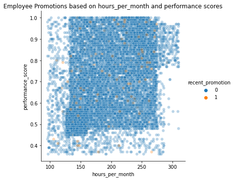

```python
# Show the relationship between hours_per_month, performance score, and recent promotion

sns.relplot(data=df_no_outliers, x="hours_per_month", y="performance_score", hue="recent_promotion", alpha=0.3)
plt.title('Employee Promotions based on hours_per_month and performance scores')
plt.show();
```

```python
# Investigate other relationships between different variables and "left"
```

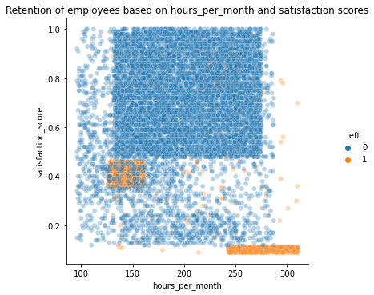

```python
# Show the relationship between hours_per_month, satisfaction score, and left

sns.relplot(data=df_no_outliers, x="hours_per_month", y="satisfaction_score", hue="left", alpha=0.3)
plt.title('Retention of employees based on hours_per_month and satisfaction scores')
plt.show();
```

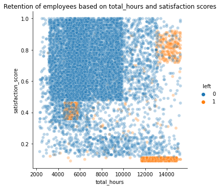

```python
# Show the relationship between total_hours, satisfaction score, and left

sns.relplot(data=df_no_outliers, x="total_hours", y="satisfaction_score", hue="left", alpha=0.3)
plt.title('Retention of employees based on total_hours and satisfaction scores')
plt.show();
```

```python
# Insights:
# 1) Overall, employees are more satisfied when they have worked less than 10,000 hours for the company,
#    and they are less likely to leave the company.
# 2) A cluster of moderately satisfied employees that work 5,000-6,000 hours over their time with the company are
#    more likely to leave the company.
# 3) Veru disatisfied employees who have worked over 11,500 hours are likely to leave the company.
# 4) A cluster of employees who are satisfied after working many hours for the company still leave the company.
```

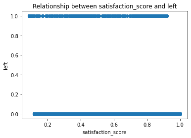

```python
# Create a scatterplot to show the relationship between satisfaction score and left
plt.scatter(df_no_outliers['satisfaction_score'], df_no_outliers['left'])
plt.xlabel('satisfaction_score')
plt.ylabel('left')
plt.title('Relationship between satisfaction_score and left')
plt.show();
```

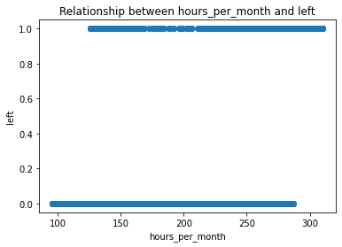

```python
# Create a scatterplot to show the relationship between hours_per_month and left
plt.scatter(df_no_outliers['hours_per_month'], df_no_outliers['left'])
plt.xlabel('hours_per_month')
plt.ylabel('left')
plt.title('Relationship between hours_per_month and left')
plt.show();
```

```python
# Insights:
# 1) Satisfied employees generally stay working with the company regardless of how many hours they work per month.
# 2) Moderately satisfied employees that work 125-175 hrs a month are more likely to leave the company.
# 3) Practically all employees who work over 290 hours a month end up leaving the company, regardless of their
#    satisfaction levels.
# 4) Employees who are very unsatisfied and work around 250 to 300 hours a month are likely to leave the company.
# 5) Most employees that work under 130 hours per month are retained by the company. This is a common threshold for
#    part time vs full time workers, though some employers set a higher threshold . Part time employees are much more likely than full-time workers to stay with the company.
# 6) However, the second graph does not show a direct linear correlation between satisfaction score
#    and left. Employees are retained and leave the company across all satisfaction scores.
```

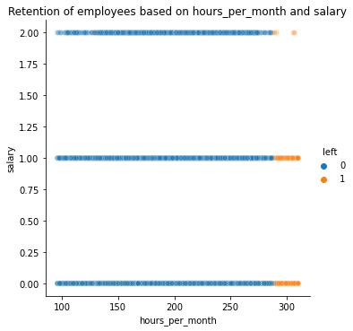

```python
# Show the relationship between hours per month, salary, and left

sns.relplot(data=df_no_outliers, x="hours_per_month", y="salary", hue="left", alpha=0.3)
plt.title('Retention of employees based on hours_per_month and salary')
plt.show();
```

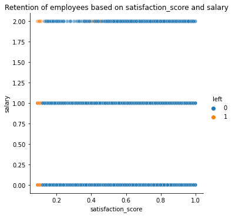

```python
# Show the relationship between satisfaction_score, salary, and left

sns.relplot(data=df_no_outliers, x="satisfaction_score", y="salary", hue="left", alpha=0.3)
plt.title('Retention of employees based on satisfaction_score and salary')
plt.show();
```

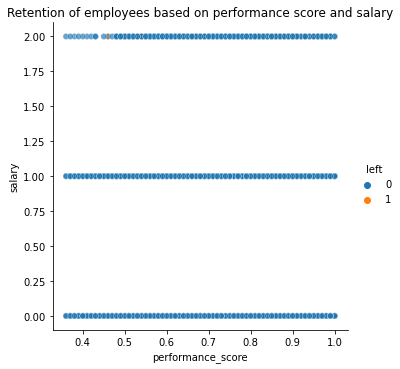

```python
# Show the relationship between performance_score, salary, and left

sns.relplot(data=df_no_outliers, x="performance_score", y="salary", hue="left", alpha=0.3)
plt.title('Retention of employees based on performance score and salary')
plt.show();
```

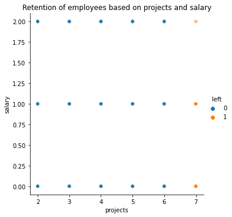

```python
# Show the relationship between projects, salary, and left

sns.relplot(data=df_no_outliers, x="projects", y="salary", hue="left", alpha=0.3)
plt.title('Retention of employees based on projects and salary')
plt.show();
```

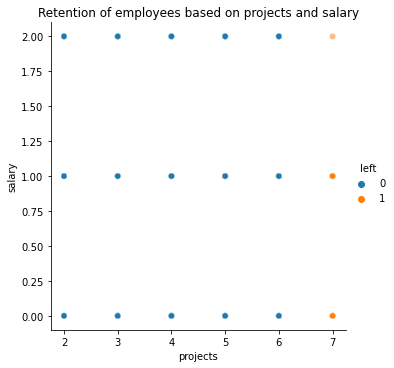

```python
# Show the relationship between hours_per_month, salary, and left

sns.relplot(data=df_no_outliers, x="projects", y="salary", hue="left", alpha=0.3)
plt.title('Retention of employees based on projects and salary')
plt.show();
```

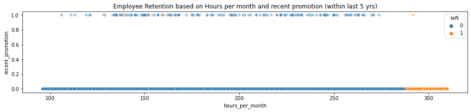

```python
# Show the relationship between `hours_per_month` and `recent_promotion`
plt.figure(figsize=(16, 3))
sns.scatterplot(data=df_no_outliers, x='hours_per_month', y='recent_promotion', hue='left', alpha=0.4)
plt.title('Employee Retention based on Hours per month and recent promotion (within last 5 yrs)')
```

```python
# Insights:
# 1) Across all three salary types, employees are more likely to leave the company if they work more hours per month.
# 2) Employees from all salary groups that are less satisfied are more likely to leave.
# 3) Performance score does not seem to affect the rate of retention across all salary groups.
# 4) Having 7 projects affects the rate of leaving the company across all salary groups. Based on an additional scatterplot,
#    all employees with 7 projects, regardless of how many hours per month they worked, left the company. Employees left the
#    company who had all numbers of projects, but having 6 projects also led to a higher rate of leaving. Additionally, employees
#    working higher hours per month across all project numbers were more likely to leave the company.
# 5) Very few employees working the highest hours_per_month received promotions. These employees were more likely to leave
#    than employees working lower amounts of hours.
# 6) Employees who have been promoted within the last 5 years are less likely to leave the company.
```

```python
# Show list of columns in df_no_outliers for reference

df_no_outliers.columns
```

```
Index(['satisfaction_score', 'performance_score', 'projects',
       'hours_per_month', 'tenure', 'work_accident', 'left',
       'recent_promotion', 'salary', 'total_hours', 'full_time', 'hard_worker',
       'high_performer', 'happy_worker'],
      dtype='object')
```

```python
# Define variables for the pairplot

x_vars = ['satisfaction_score', 'performance_score', 'projects',
       'hours_per_month', 'tenure', 'work_accident', 'left',
       'recent_promotion', 'salary', 'total_hours', 'full_time', 'hard_worker',
       'high_performer', 'happy_worker']
y_vars = ['left']
```

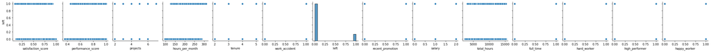

```python
# Complete a selective pairplot for all columns agains left.

%matplotlib inline
sns.pairplot(data = df_no_outliers, x_vars = x_vars, y_vars = y_vars)
plt.show();
```

```python
# Create a correlation matrix for the logistic regression

df_no_outliers.corr(method='pearson')
```

|  | satisfaction_score | performance_score | projects | hours_per_month | tenure | work_accident | left | recent_promotion | salary | total_hours | full_time | hard_worker | high_performer | happy_worker |
| --- | --- | --- | --- | --- | --- | --- | --- | --- | --- | --- | --- | --- | --- | --- |
| satisfaction_score | 1.000000 | 0.093399 | -0.120332 | 0.002480 | -0.226580 | 0.048567 | -0.433586 | 0.026822 | 0.039707 | -0.184005 | 0.116419 | -0.093877 | 0.030119 | 0.800677 |
| performance_score | 0.093399 | 1.000000 | 0.272193 | 0.251765 | 0.105602 | 0.007915 | -0.063370 | -0.001366 | -0.007894 | 0.246218 | 0.131952 | 0.161378 | 0.649817 | 0.148159 |
| projects | -0.120332 | 0.272193 | 1.000000 | 0.326709 | 0.228529 | 0.000606 | -0.020746 | 0.006661 | 0.003802 | 0.386445 | 0.095208 | 0.250135 | 0.134060 | 0.036942 |
| hours_per_month | 0.002480 | 0.251765 | 0.326709 | 1.000000 | 0.067189 | -0.000822 | -0.000680 | -0.007405 | 0.007591 | 0.675436 | 0.394630 | 0.751212 | 0.113059 | 0.086843 |
| tenure | -0.226580 | 0.105602 | 0.228529 | 0.067189 | 1.000000 | -0.022919 | 0.272347 | -0.008954 | -0.023104 | 0.762144 | -0.069533 | 0.079001 | 0.098475 | -0.065793 |
| work_accident | 0.048567 | 0.007915 | 0.000606 | -0.000822 | -0.022919 | 1.000000 | -0.116926 | 0.022695 | -0.000219 | -0.024757 | 0.006154 | -0.011723 | -0.000460 | 0.020010 |
| left | -0.433586 | -0.063370 | -0.020746 | -0.000680 | 0.272347 | -0.116926 | 1.000000 | -0.036870 | -0.110995 | 0.242554 | -0.034856 | 0.110448 | 0.028722 | -0.243401 |
| recent_promotion | 0.026822 | -0.001366 | 0.006661 | -0.007405 | -0.008954 | 0.022695 | -0.036870 | 1.000000 | 0.068840 | -0.013661 | -0.000160 | -0.006407 | 0.244361 | 0.023078 |
| salary | 0.039707 | -0.007894 | 0.003802 | 0.007591 | -0.023104 | -0.000219 | -0.110995 | 0.068840 | 1.000000 | -0.017116 | -0.005122 | -0.000514 | -0.001555 | 0.013687 |
| total_hours | -0.184005 | 0.246218 | 0.386445 | 0.675436 | 0.762144 | -0.024757 | 0.242554 | -0.013661 | -0.017116 | 1.000000 | 0.215069 | 0.527330 | 0.151579 | 0.000744 |
| full_time | 0.116419 | 0.131952 | 0.095208 | 0.394630 | -0.069533 | 0.006154 | -0.034856 | -0.000160 | -0.005122 | 0.215069 | 1.000000 | 0.130870 | 0.045822 | 0.110875 |
| hard_worker | -0.093877 | 0.161378 | 0.250135 | 0.751212 | 0.079001 | -0.011723 | 0.110448 | -0.006407 | -0.000514 | 0.527330 | 0.130870 | 1.000000 | 0.078623 | 0.000301 |
| high_performer | 0.030119 | 0.649817 | 0.134060 | 0.113059 | 0.098475 | -0.000460 | 0.028722 | 0.244361 | -0.001555 | 0.151579 | 0.045822 | 0.078623 | 1.000000 | 0.062936 |
| happy_worker | 0.800677 | 0.148159 | 0.036942 | 0.086843 | -0.065793 | 0.020010 | -0.243401 | 0.023078 | 0.013687 | 0.000744 | 0.110875 | 0.000301 | 0.062936 | 1.000000 |

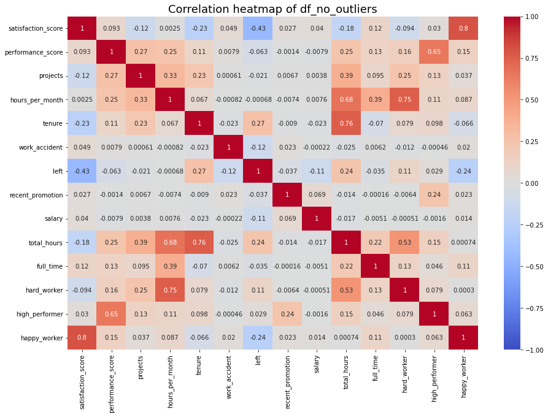

```python
# Create a correlation heatmap
plt.figure(figsize=(15,10))
sns.heatmap(df_no_outliers.corr(method='pearson'), vmin=-1, vmax=1, annot=True, cmap='coolwarm')
plt.title('Correlation heatmap of df_no_outliers',
          fontsize=18)
plt.show();
```

### Insights

I was left with the following impressions: 1) Employees who leave tend to be unsatisfied and overworked (work very high average hours_per_month and/or have many projects). Employees who are satsified do leave the company, but these employees do tend to be overworked. The other significant category of people who leave are those with moderately low performance scores and moderately low satisfaction scores. 2) Employees who are satisfied are less likely to leave the company. 3) Employees within the high salary category are less likely than the low and medium salary employees to leave the company. However, employees form all salary categories are likely to leave the company if they are overworked or have 6-7 projects. Disatisfied employees are more likely to leave the company, regardless of what category salary they are in. 4) Employees working under 130 hours per month (part-time) are less likely to leave the company than employees who work longer monthly hours. 5) Employees who have received recent promotions (within the last 5 years) are less likely to leave the company. The employees who work the longest hours per month for the company are the least likely to receive promotions and these employees also frequently leave the company. 6) Employees across all departments are equally likely to leave the company. The difference in retention rates among departments is not statistically significant. Department is not a predictive variable to base a model on. The HR department can conclude that this evidence suggests that there is not a major issue among specific departments affecting employee retention rate. This also suggests the HR department can focus implementing solutions more broadly among the employee population than tailoring the approach to select departments.

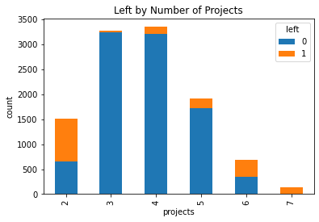

```python
# Visualize the distribution of left among number of projects

pd.crosstab(df_no_outliers['projects'],df_no_outliers['left']).plot.bar(stacked=True)
plt.title('Left by Number of Projects')
plt.ylabel('count')
plt.show();
```

```python
# Add a binary variable to identify if an employee is overworked
# Overwork will be defined as working for 1.5X the normal hours a month for full time(1.5*130=195), working 6-7 projects
df['overworked'] = np.where((df['hours_per_month'] >= 195) | (df['projects'] >= 6), 1, 0)

df['overworked'].describe()
```

```
count    11991.000000
mean         0.546743
std          0.497831
min          0.000000
25%          0.000000
50%          1.000000
75%          1.000000
max          1.000000
Name: overworked, dtype: float64
```

```python
# Repeat process for no outliers df

df_no_outliers['overworked'] = np.where((df_no_outliers['hours_per_month'] >= 195) | (df_no_outliers['projects'] >= 6), 1, 0)

df_no_outliers['overworked'].describe()
```

```
count    10865.000000
mean         0.527658
std          0.499257
min          0.000000
25%          0.000000
50%          1.000000
75%          1.000000
max          1.000000
Name: overworked, dtype: float64
```

```python
# Add a binary variable to identify if an employee is underappreciated
# underappreciated will be defined as having only 2 projects, having a high performance score and no promotion in the last 5 years

df['under_appreciated'] = np.where((df['projects'] == 2) | ((df['performance_score'] > 0.9) & (df['recent_promotion'] == 0)), 1, 0)

df['under_appreciated'].describe()
```

```
count    11991.000000
mean         0.295388
std          0.456236
min          0.000000
25%          0.000000
50%          0.000000
75%          1.000000
max          1.000000
Name: under_appreciated, dtype: float64
```

```python
# Repeat process for the no outlier df

df_no_outliers['under_appreciated'] = np.where((df_no_outliers['projects'] == 2) | ((df_no_outliers['performance_score'] > 0.9) & (df_no_outliers['recent_promotion'] == 0)), 1, 0)

df_no_outliers['under_appreciated'].describe()
```

```
count    10865.000000
mean         0.295076
std          0.456098
min          0.000000
25%          0.000000
50%          0.000000
75%          1.000000
max          1.000000
Name: under_appreciated, dtype: float64
```

```python
# I have concerns about 2 aspects regarding the variables.

# 1) Satisfaction_score- These are self-reported and the only subjective variable in the dataset. I am concerned about
#    creating a model that is heavily influenced by this variable. The company may not have accurate information about
#    satisfaction scores for all employees, as with voluntary surveys typically the individuals with the strongest feelings
#    are more likely to respond than neutral individuals, and the information the company gets may not necessarily be true,
#    as employees may be reluctant to report their true feelings. The variable I created called happy_worker also relies on
#    this variable. The correlation heatmap shows that satisfaction socres is predicted to be very influential in the model.
#    We already know that higher employee satisfaction has an overall positive relationship to employees being retained by
#    the company. In the future, the company may not have this variable for all employees. I will build a model without this
#    variable.

# 2) Hours_per_month- I am mildly concerned that this could be impacted because it is possible that employees who are planning
#    to quit but haven't given notice could deliberately work less hours. If employees are contracted a certain number of hours
#    per week, the company could use the contracted number of hours. However, its more complicated with salaried employees.
#    Ensuring the company uses the average number of hours worked monthly since the beginning of their employment would
#    help reduce the impact of this on the model's quality. This variable should have a much lower impact on the model created,
#    so I will retain it within the dataset.
```

```python
# Drop the satisfaction_score variable and happy worker from both dfs

df = df.drop(columns=['satisfaction_score', 'happy_worker'])

df_no_outliers = df_no_outliers.drop(columns=['satisfaction_score', 'happy_worker'])

df_no_outliers.head()
```

|  | performance_score | projects | hours_per_month | tenure | work_accident | left | recent_promotion | salary | total_hours | full_time | hard_worker | high_performer | overworked | under_appreciated |
| --- | --- | --- | --- | --- | --- | --- | --- | --- | --- | --- | --- | --- | --- | --- |
| 0 | 0.53 | 2 | 157 | 3 | 0 | 1 | 0 | 0 | 5652 | 1 | 0 | 0 | 0 | 1 |
| 1 | 0.88 | 7 | 272 | 4 | 0 | 1 | 0 | 1 | 13056 | 1 | 1 | 0 | 1 | 0 |
| 2 | 0.87 | 5 | 223 | 5 | 0 | 1 | 0 | 0 | 13380 | 1 | 0 | 0 | 1 | 0 |
| 3 | 0.52 | 2 | 159 | 3 | 0 | 1 | 0 | 0 | 5724 | 1 | 0 | 0 | 0 | 1 |
| 4 | 0.50 | 2 | 153 | 3 | 0 | 1 | 0 | 0 | 5508 | 1 | 0 | 0 | 0 | 1 |

```python
# Create a 2nd correlation matrix for the logistic regression

df_no_outliers.corr(method='pearson')
```

|  | performance_score | projects | hours_per_month | tenure | work_accident | left | recent_promotion | salary | total_hours | full_time | hard_worker | high_performer | overworked | under_appreciated |
| --- | --- | --- | --- | --- | --- | --- | --- | --- | --- | --- | --- | --- | --- | --- |
| performance_score | 1.000000 | 0.272193 | 0.251765 | 0.105602 | 0.007915 | -0.063370 | -0.001366 | -0.007894 | 0.246218 | 0.131952 | 0.161378 | 0.649817 | 0.210545 | 0.258159 |
| projects | 0.272193 | 1.000000 | 0.326709 | 0.228529 | 0.000606 | -0.020746 | 0.006661 | 0.003802 | 0.386445 | 0.095208 | 0.250135 | 0.134060 | 0.328192 | -0.332247 |
| hours_per_month | 0.251765 | 0.326709 | 1.000000 | 0.067189 | -0.000822 | -0.000680 | -0.007405 | 0.007591 | 0.675436 | 0.394630 | 0.751212 | 0.113059 | 0.829460 | -0.132835 |
| tenure | 0.105602 | 0.228529 | 0.067189 | 1.000000 | -0.022919 | 0.272347 | -0.008954 | -0.023104 | 0.762144 | -0.069533 | 0.079001 | 0.098475 | 0.086694 | 0.070325 |
| work_accident | 0.007915 | 0.000606 | -0.000822 | -0.022919 | 1.000000 | -0.116926 | 0.022695 | -0.000219 | -0.024757 | 0.006154 | -0.011723 | -0.000460 | 0.004954 | -0.041900 |
| left | -0.063370 | -0.020746 | -0.000680 | 0.272347 | -0.116926 | 1.000000 | -0.036870 | -0.110995 | 0.242554 | -0.034856 | 0.110448 | 0.028722 | -0.048915 | 0.387064 |
| recent_promotion | -0.001366 | 0.006661 | -0.007405 | -0.008954 | 0.022695 | -0.036870 | 1.000000 | 0.068840 | -0.013661 | -0.000160 | -0.006407 | 0.244361 | -0.000570 | -0.054993 |
| salary | -0.007894 | 0.003802 | 0.007591 | -0.023104 | -0.000219 | -0.110995 | 0.068840 | 1.000000 | -0.017116 | -0.005122 | -0.000514 | -0.001555 | 0.011998 | -0.056159 |
| total_hours | 0.246218 | 0.386445 | 0.675436 | 0.762144 | -0.024757 | 0.242554 | -0.013661 | -0.017116 | 1.000000 | 0.215069 | 0.527330 | 0.151579 | 0.569340 | -0.020422 |
| full_time | 0.131952 | 0.095208 | 0.394630 | -0.069533 | 0.006154 | -0.034856 | -0.000160 | -0.005122 | 0.215069 | 1.000000 | 0.130870 | 0.045822 | 0.205415 | -0.076228 |
| hard_worker | 0.161378 | 0.250135 | 0.751212 | 0.079001 | -0.011723 | 0.110448 | -0.006407 | -0.000514 | 0.527330 | 0.130870 | 1.000000 | 0.078623 | 0.537770 | -0.052066 |
| high_performer | 0.649817 | 0.134060 | 0.113059 | 0.098475 | -0.000460 | 0.028722 | 0.244361 | -0.001555 | 0.151579 | 0.045822 | 0.078623 | 1.000000 | 0.100804 | 0.593196 |
| overworked | 0.210545 | 0.328192 | 0.829460 | 0.086694 | 0.004954 | -0.048915 | -0.000570 | 0.011998 | 0.569340 | 0.205415 | 0.537770 | 0.100804 | 1.000000 | -0.130837 |
| under_appreciated | 0.258159 | -0.332247 | -0.132835 | 0.070325 | -0.041900 | 0.387064 | -0.054993 | -0.056159 | -0.020422 | -0.076228 | -0.052066 | 0.593196 | -0.130837 | 1.000000 |

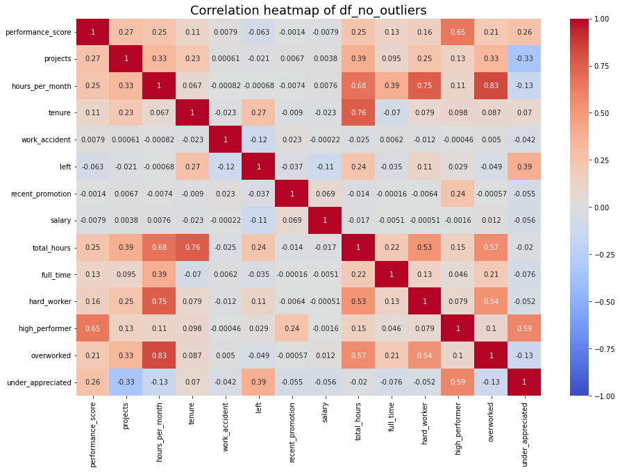

```python
# Create a 2nd correlation heatmap
plt.figure(figsize=(15,10))
sns.heatmap(df_no_outliers.corr(method='pearson'), vmin=-1, vmax=1, annot=True, cmap='coolwarm')
plt.title('Correlation heatmap of df_no_outliers',
          fontsize=18)
plt.show();
```

# paCe: Construct Stage

- Determine which models are most appropriate
- Construct the model
- Confirm model assumptions
- Evaluate model results to determine how well your model fits the data

🔎

## Recall model assumptions

**Logistic Regression model assumptions**

- Outcome variable is categorical
- Observations are independent of each other
- No severe multicollinearity among X variables
- No extreme outliers
- Linear relationship between each X variable and the logit of the outcome variable
- Sufficiently large sample size

💭

### Reflect on these questions as you complete the constructing stage.

- Which independent variables did you choose for the model and why?
- Are each of the assumptions met?
- How well does your model fit the data?
- Can you improve it? Is there anything you would change about the model?
- What resources do you find yourself using as you complete this stage?
- Do you have any ethical considerations in this stage?

1) I am going to run multiple models and compare. This data is appropriate for a binary logistic regression model, so I can run a logistic regression model and tree-based machine learning models, including decision tree and random forest. For the logistic regression, I need to be cautious about multicollinearity among the X variables. When variables have a Pearson correlation coefficient value greater than the absolute value of 0.7 with each other, these variables are strongly multicollinear and I will select the variable that has the highest correlation with 'left', which is the binary target variable. I am using the df_no_outliers for the logistic regression model.

The following variables are strongly multicollinear:

- hours per month & hard worker (0.75)
- hours per month & overworked (0.83)
- tenure & total hours (0.76)

Out of these variables, I have selected hard worker, overworked and tenure to be used in the X variables. Hours per month and total hours must be dropped from df_no_outliers. The X variables will be hard worker, overworked, tenure, performance scores, projects, work accident, recent promotion, salary, full time, high performer, overworked, and under appreciated. The y variable will be left.

2) All the assumptions I can make prior to actually building the model have been met.

3) The data fits all the models well. They all do an acceptable job at correctly identifying the individuals who will leave (recall score). My champion model is the random forest model because it has the best combination of scores for meeting the company's needs.

4) The model could potentially be improved but it would take more computational time and resources. This could be done by obtaining additional data, creating more engineered variables, and varying the parameters.

5) At this stage, I have used previous projects to guide the process of creating a model and check the correct syntax to use in python.

6) I do not have any ethical concerns at this stage. The model will likely improve the experience for employees at the company. Any incorrect guesses the model makes likely won't cause any harm and will result in the same outcome as not having the model- employees leaving the company, or individuals who would have stayed at the company receiving interventions that generally increase the rate of employees staying at the company.

## Step 3. Model Building, Step 4. Results and Evaluation

- Fit a model that predicts the outcome variable using two or more independent variables
- Check model assumptions
- Evaluate the model

### Identify the type of prediction task.

This is a binary classification task.

### Identify the types of models most appropriate for this task.

The models most appropriate for this task are a logistic regression model and tree-based machine learning models, including a decision tree model and a random forest model.